# AMS 580 Final Exam

Kachun Huang

2025-05-14

# AMS 580 Final Exam **Seat Number C5**

# Task 1

## Import Library

```r
library(dplyr)
library(caret)
library(randomForest)
library(xgboost)
library(Matrix)
library(keras)
library(tensorflow)
library(reticulate)
library(tidyverse)
library(tidyquant)
library(zoo)
library(magrittr)
```

## Import Data

```r
data1 <- read.csv("/Users/thomashuang/Downloads/data_1.csv")
head(data1)
```

|  | Age | Gender | Occupation | Sleep.Hours | Physical.Activity..hrs.week. | Caffeine.Intake..mg.day. | Alcohol.Consumption..drinks.week. | Smoking | Family.History.of.Anxiety | Stress.Level..1.10. | Heart.Rate..bpm. | Breathing.Rate..breaths.min. | Sweating.Level..1.5. | Dizziness | Medication | Therapy.Sessions..per.month. | Recent.Major.Life.Event | Diet.Quality..1.10. | Anxiety.Level..1.10. |
| --- | --- | --- | --- | --- | --- | --- | --- | --- | --- | --- | --- | --- | --- | --- | --- | --- | --- | --- | --- |
| 1 | 29 | Female | Artist | 6.0 | 2.7 | 181 | 10 | Yes | No | 10 | 114 | 14 | 4 | No | Yes | 3 | Yes | 7 | 5 |
| 2 | 46 | Other | Nurse | 6.2 | 5.7 | 200 | 8 | Yes | Yes | 1 | 62 | 23 | 2 | Yes | No | 2 | No | 8 | 3 |
| 3 | 64 | Male | Other | 5.0 | 3.7 | 117 | 4 | No | Yes | 1 | 91 | 28 | 3 | No | No | 1 | Yes | 1 | 1 |
| 4 | 20 | Female | Scientist | 5.8 | 2.8 | 360 | 6 | Yes | No | 4 | 86 | 17 | 3 | No | No | 0 | No | 1 | 2 |
| 5 | 49 | Female | Other | 8.2 | 2.3 | 247 | 4 | Yes | No | 1 | 98 | 19 | 4 | Yes | Yes | 1 | No | 3 | 1 |
| 6 | 53 | Male | Other | 6.4 | 6.5 | 235 | 2 | No | No | 9 | 84 | 14 | 3 | No | Yes | 2 | Yes | 5 | 4 |

```r
str(data1)
```

```
## 'data.frame':    1100 obs. of  19 variables:
##  $ Age                              : int  29 46 64 20 49 53 20 54 51 59 ...
##  $ Gender                           : chr  "Female" "Other" "Male" "Female" ...
##  $ Occupation                       : chr  "Artist" "Nurse" "Other" "Scientist" ...
##  $ Sleep.Hours                      : num  6 6.2 5 5.8 8.2 6.4 7.9 6.3 6.6 5.1 ...
##  $ Physical.Activity..hrs.week.     : num  2.7 5.7 3.7 2.8 2.3 6.5 2.5 5.5 3.1 4.8 ...
##  $ Caffeine.Intake..mg.day.         : int  181 200 117 360 247 235 78 535 587 159 ...
##  $ Alcohol.Consumption..drinks.week.: int  10 8 4 6 4 2 14 15 2 15 ...
##  $ Smoking                          : chr  "Yes" "Yes" "No" "Yes" ...
##  $ Family.History.of.Anxiety        : chr  "No" "Yes" "Yes" "No" ...
##  $ Stress.Level..1.10.              : int  10 1 1 4 1 9 8 5 2 5 ...
##  $ Heart.Rate..bpm.                 : int  114 62 91 86 98 84 118 113 81 95 ...
##  $ Breathing.Rate..breaths.min.     : int  14 23 28 17 19 14 21 19 22 28 ...
##  $ Sweating.Level..1.5.             : int  4 2 3 3 4 3 5 1 1 5 ...
##  $ Dizziness                        : chr  "No" "Yes" "No" "No" ...
##  $ Medication                       : chr  "Yes" "No" "No" "No" ...
##  $ Therapy.Sessions..per.month.     : int  3 2 1 0 1 2 1 0 2 1 ...
##  $ Recent.Major.Life.Event          : chr  "Yes" "No" "Yes" "No" ...
##  $ Diet.Quality..1.10.              : int  7 8 1 1 3 5 2 7 8 1 ...
##  $ Anxiety.Level..1.10.             : int  5 3 1 2 1 4 4 4 3 4 ...
```

## Data Cleaning

### Remove Missing rows

```r
data1 <- na.omit(data1)
str(data1)
```

```
## 'data.frame':    1100 obs. of  19 variables:
##  $ Age                              : int  29 46 64 20 49 53 20 54 51 59 ...
##  $ Gender                           : chr  "Female" "Other" "Male" "Female" ...
##  $ Occupation                       : chr  "Artist" "Nurse" "Other" "Scientist" ...
##  $ Sleep.Hours                      : num  6 6.2 5 5.8 8.2 6.4 7.9 6.3 6.6 5.1 ...
##  $ Physical.Activity..hrs.week.     : num  2.7 5.7 3.7 2.8 2.3 6.5 2.5 5.5 3.1 4.8 ...
##  $ Caffeine.Intake..mg.day.         : int  181 200 117 360 247 235 78 535 587 159 ...
##  $ Alcohol.Consumption..drinks.week.: int  10 8 4 6 4 2 14 15 2 15 ...
##  $ Smoking                          : chr  "Yes" "Yes" "No" "Yes" ...
##  $ Family.History.of.Anxiety        : chr  "No" "Yes" "Yes" "No" ...
##  $ Stress.Level..1.10.              : int  10 1 1 4 1 9 8 5 2 5 ...
##  $ Heart.Rate..bpm.                 : int  114 62 91 86 98 84 118 113 81 95 ...
##  $ Breathing.Rate..breaths.min.     : int  14 23 28 17 19 14 21 19 22 28 ...
##  $ Sweating.Level..1.5.             : int  4 2 3 3 4 3 5 1 1 5 ...
##  $ Dizziness                        : chr  "No" "Yes" "No" "No" ...
##  $ Medication                       : chr  "Yes" "No" "No" "No" ...
##  $ Therapy.Sessions..per.month.     : int  3 2 1 0 1 2 1 0 2 1 ...
##  $ Recent.Major.Life.Event          : chr  "Yes" "No" "Yes" "No" ...
##  $ Diet.Quality..1.10.              : int  7 8 1 1 3 5 2 7 8 1 ...
##  $ Anxiety.Level..1.10.             : int  5 3 1 2 1 4 4 4 3 4 ...
```

After Remove NAs, there are 1100 observations left.

## Data Splitting

```r
set.seed(2025)
train_idx <- createDataPartition(data1$Anxiety.Level..1.10., p = 0.75, list = FALSE)
train_data1 <- data1[train_idx, ]
test_data1 <- data1[-train_idx, ]
```

For Random Forest

```r
train_data1_rf <- train_data1
train_data1_rf$Gender <- factor(train_data1$Gender)
train_data1_rf$Occupation <- factor(train_data1$Occupation)
train_data1_rf$Smoking <- factor(train_data1$Smoking)
train_data1_rf$Family.History.of.Anxiety <- factor(train_data1$Family.History.of.Anxiety)
train_data1_rf$Dizziness  <- factor(train_data1$Dizziness)
train_data1_rf$Medication  <- factor(train_data1$Medication)
train_data1_rf$Recent.Major.Life.Event <- factor(train_data1$Recent.Major.Life.Event )

test_data1_rf <- test_data1
test_data1_rf$Gender <- factor(test_data1$Gender)
test_data1_rf$Occupation <- factor(test_data1$Occupation)
test_data1_rf$Smoking <- factor(test_data1$Smoking)
test_data1_rf$Family.History.of.Anxiety <- factor(test_data1$Family.History.of.Anxiety)
test_data1_rf$Dizziness  <- factor(test_data1$Dizziness)
test_data1_rf$Medication  <- factor(test_data1$Medication)
test_data1_rf$Recent.Major.Life.Event <- factor(test_data1$Recent.Major.Life.Event )
```

For XgBoost

```r
# Prepare data for XGBoost
X_train <- model.matrix(Anxiety.Level..1.10. ~., data = train_data1)
y_train <- train_data1$Anxiety.Level..1.10.
X_test <- model.matrix(Anxiety.Level..1.10. ~., data = test_data1)
y_test <- test_data1$Anxiety.Level..1.10.
```

## RandomForest

```r
set.seed(2025)

# 10-fold CV
control <- trainControl(
  method = "cv",
  number = 10
  )

# train the rf using 10-fold CV
model <- caret::train(
  Anxiety.Level..1.10. ~ .,
  data = train_data1_rf,
  method = "rf",
  trControl = control
  )
```

BestTune

```r
model$bestTune
```

|  | mtry |
| --- | --- |
| 2 | 16 |

Variable Importance as barplot

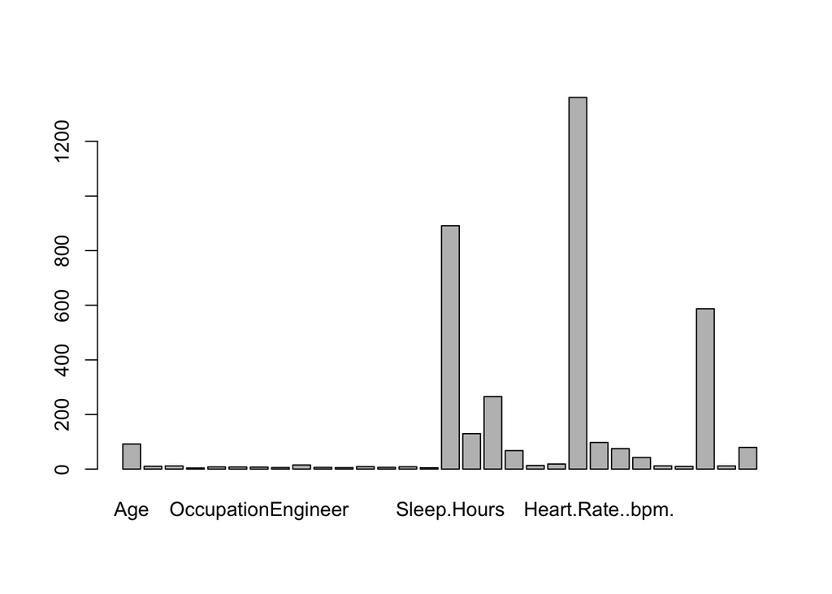

```r
final_model <- model$finalModel
barplot(randomForest::importance(final_model)[,"IncNodePurity"])
```

```r
set.seed(2025)
rf <- randomForest(
  Anxiety.Level..1.10.~.,
  data=train_data1_rf,
  mtry=16,
  keep.forest=FALSE, #not save each individual CART tree in the output
  importance=TRUE
)
```

### RMSE

```r
sqrt(rf$mse[500])
```

```
## [1] 1.104186
```

## XgBoost

```r
dtrain <- xgb.DMatrix(data = X_train, label = y_train)
dtest <- xgb.DMatrix(data = X_test, label = y_test)
```

```r
# Train XGBoost
xgb_model <- xgboost(
  data = dtrain,
  nrounds = 500,
  eta = 0.1,
  verbose = 0
)
```

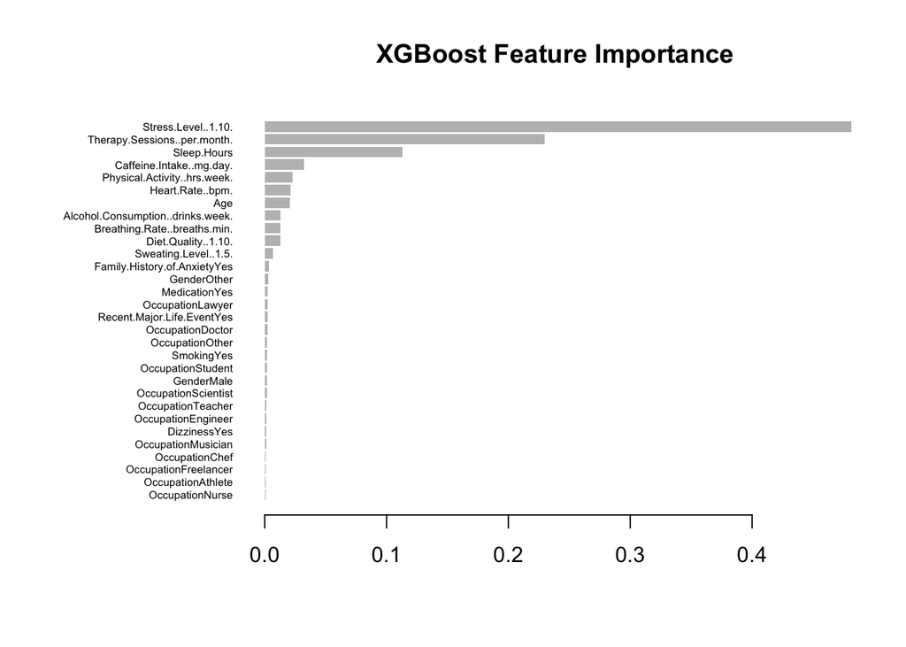

```r
# Feature importance plot
importance <- xgb.importance(feature_names = colnames(X_train), model = xgb_model)
xgb.plot.importance(importance, main = "XGBoost Feature Importance")
```

Prediction

```r
xgb_preds <- predict(xgb_model, X_test)
```

RMSE

```r
sqrt(mean((y_test - xgb_preds)^2))
```

```
## [1] 1.165522
```

## Comparison

- RF: 1.104186
- XGB: 1.165522

The reason why RF outperform XGB

- Number of Features- since XGB used one-hot-encoding so there is a risk of multicolinearity problem which overfit the training data
- Cross-Validation: since we used cross validation to find the optimal mtry for rf and in XGB, we didn’t use CV to tune hyper-parameter. It can result in RF performs better than XGB

# Task 2

## Import Data

```r
data2 <- read.csv("/Users/thomashuang/Downloads/data_2.csv")
data2$Date = as.Date(data2$Date)
head(data2)
```

|  | Date | AMZN.Open | AMZN.High | AMZN.Low | AMZN.Close | AMZN.Volume | AMZN.Adjusted |
| --- | --- | --- | --- | --- | --- | --- | --- |
| 1 | 2023-01-03 | 85.46 | 86.96 | 84.21 | 85.82 | 76706000 | 85.82 |
| 2 | 2023-01-04 | 86.55 | 86.98 | 83.36 | 85.14 | 68885100 | 85.14 |
| 3 | 2023-01-05 | 85.33 | 85.42 | 83.07 | 83.12 | 67930800 | 83.12 |
| 4 | 2023-01-06 | 83.03 | 86.40 | 81.43 | 86.08 | 83303400 | 86.08 |
| 5 | 2023-01-09 | 87.46 | 89.48 | 87.08 | 87.36 | 65266100 | 87.36 |
| 6 | 2023-01-10 | 87.57 | 90.19 | 87.29 | 89.87 | 67756600 | 89.87 |

```r
str(data2)
```

```
## 'data.frame':    590 obs. of  7 variables:
##  $ Date         : Date, format: "2023-01-03" "2023-01-04" ...
##  $ AMZN.Open    : num  85.5 86.6 85.3 83 87.5 ...
##  $ AMZN.High    : num  87 87 85.4 86.4 89.5 ...
##  $ AMZN.Low     : num  84.2 83.4 83.1 81.4 87.1 ...
##  $ AMZN.Close   : num  85.8 85.1 83.1 86.1 87.4 ...
##  $ AMZN.Volume  : int  76706000 68885100 67930800 83303400 65266100 67756600 103126200 85254800 85549400 72755000 ...
##  $ AMZN.Adjusted: num  85.8 85.1 83.1 86.1 87.4 ...
```

## 1. Data preprocessing and visualization

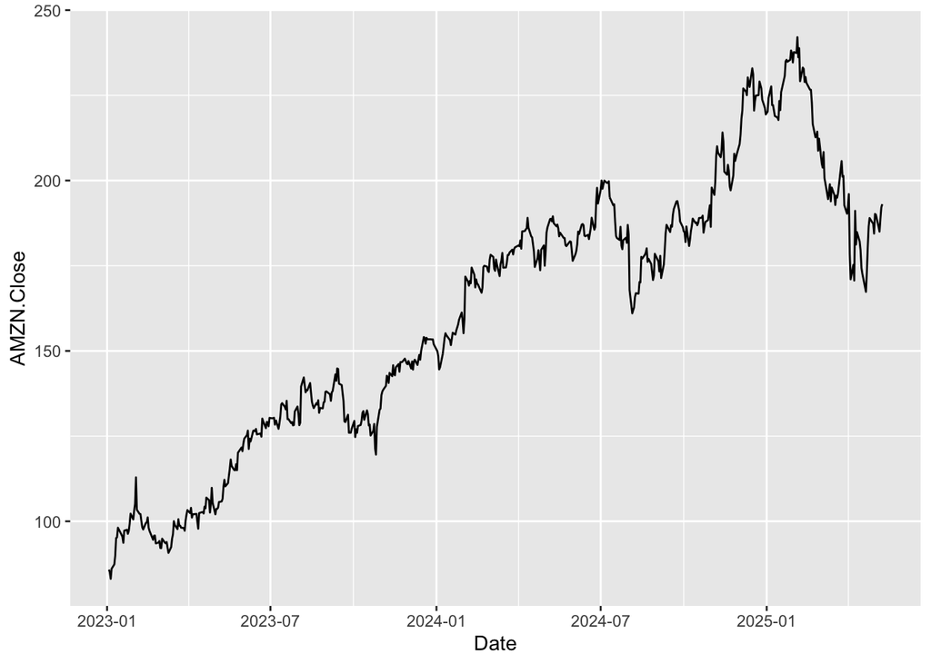

```r
ggplot(
  data2,
  aes(x=Date, y = AMZN.Close)
) + geom_line()
```

normalization

```r
data2$min_lagged = lag(data2$AMZN.Low)
data2$max_lagged = lag(data2$AMZN.High)

data2$Close_norm = (data2$AMZN.Close - data2$min_lagged) / (data2$max_lagged -data2$min_lagged)
```

```r
model_data <- matrix(
  data2$Close_norm[-1] #excluding volume
)
tail(model_data,10)
```

```
##                [,1]
## [580,]  0.496627634
## [581,]  0.469042991
## [582,]  0.170507723
## [583,]  1.830644586
## [584,]  0.575405367
## [585,] -0.007714153
## [586,] -0.196228479
## [587,]  1.191180540
## [588,]  1.182273300
## [589,]  0.769508977
```

## 2. Data Splitting

```r
set.seed(2025)

# Create sliding window dataset
create_dataset <- function(series, timesteps = 10) {
  x <- list()
  y <- c()
  for (i in 1:(length(series) - timesteps)) {
  x[[i]] <- series[i:(i + timesteps - 1)]
  y <- c(y, series[i + timesteps])
  }
  x_array <- do.call(rbind, x)
  return(list(x = x_array, y = y))
}

# Prepare training data
timesteps <- 10

train_data2 <- model_data[1:(length(model_data)-10)] # training = all except last 10 days

test_data2 <- model_data[(length(model_data)-9):length(model_data)] # true last 10 points

train_set2 <- create_dataset(train_data2, timesteps)

x_train_array <- array(
  as.numeric(train_set2$x),
  dim = c(nrow(train_set2$x), timesteps, 1)
)

y_train_array <- as.numeric(train_set2$y)

x_train2 <- tf$convert_to_tensor(
  x_train_array,
  dtype = "float32"
)

y_train2 <- tf$convert_to_tensor(
  y_train_array,
  dtype = "float32"
)

dim(x_train2)
```

```
## [1] 569  10   1
```

The dimension of the training data is 569(rows) and 10(columns)

## LSTM

```r
input_lstm <- layer_input(shape = c(timesteps, 1))

output_lstm <- input_lstm %>%
  layer_lstm(units = 32) %>%
  layer_dense(units = 1)

model_lstm <- keras_model(inputs = input_lstm, outputs = output_lstm)

model_lstm$compile(
  loss = "mean_squared_error"
)

history_lstm <- model_lstm$fit(
  x = x_train2,
  y = y_train2,
  epochs = r_to_py(100L),
  batch_size = r_to_py(16L),
  verbose = 0
)
```

## RNN

```r
input_rnn <- layer_input(shape = c(timesteps, 1))

output_rnn <- input_rnn %>%
  layer_simple_rnn(units = 32) %>%
  layer_dense(units = 1)

model_rnn <- keras_model(inputs = input_rnn, outputs = output_rnn)

model_rnn$compile(
  loss = "mean_squared_error"
)

history_rnn <- model_rnn$fit(
  x = x_train2,
  y = y_train2,
  epochs = r_to_py(100L),
  batch_size = r_to_py(16L),
  verbose = 0
)
```

```r
# Prepare input for forecasting
input_seq <- model_data[(length(model_data)-10):(length(model_data)-1)] # 10 points before test

input_seq_array <- array(as.numeric(input_seq), dim = c(1, timesteps,1))

input_seq_array <- tf$convert_to_tensor(input_seq_array, dtype = "float32")

# Prediction function
predict_next <- function(model, input_seq_array, n_steps = 10) {
  preds <- c()
  current_input <- input_seq_array
  for (i in 1:n_steps) {
    pred <- model$predict(current_input)
    preds <- c(preds, as.numeric(pred))
    updated_seq <- c(as.numeric(current_input)[-1], as.numeric(pred))
    current_input <- array(updated_seq, dim = c(1, timesteps, 1))
    current_input <- tf$convert_to_tensor(current_input, dtype = "float32")
  }
  return(preds)
}
```

```r
lstm_preds_norm <- predict_next(
  model_lstm,
  input_seq_array,
  n_steps = 10
)
```

[output not shown]

```r
rnn_preds_norm <- predict_next(
  model_rnn,
  input_seq_array,
  n_steps = 10
)
```

[output not shown]

Scale Back

```r
# Initialize vectors to store scaled-back predictions and true prices
lstm_preds_original <- numeric(10)
true_prices_original <- numeric(10)
rnn_preds_original <- numeric(10)

# Scale back one by one (because each day uses its own lagged High/Low)
for (i in 1:10) {
  lagged_min <- data2$AMZN.Low[length(train_data2) + i - 1] # lag(Low) for that day
  lagged_max <- data2$AMZN.High[length(train_data2) + i - 1] # lag(High) for that day
  rnn_preds_original[i] <- rnn_preds_norm[i] * (lagged_max - lagged_min) + lagged_min
  lstm_preds_original[i] <- lstm_preds_norm[i] * (lagged_max - lagged_min) + lagged_min
  true_prices_original[i] <- data2$AMZN.Close[length(train_data2) + i] # true Close at day
}
```

MSE

```r
mse_rnn <- mean((rnn_preds_original - true_prices_original)^2)

mse_lstm <- mean((lstm_preds_original - true_prices_original)^2)

cat("Test MSE (RNN, original scale):", mse_rnn, "\n")
```

```
## Test MSE (RNN, original scale): 13.8112
```

```r
cat("Test MSE (LSTM, original scale):", mse_lstm, "\n")
```

```
## Test MSE (LSTM, original scale): 13.87411
```

Plot 10-Day Forecast (Original Scale)

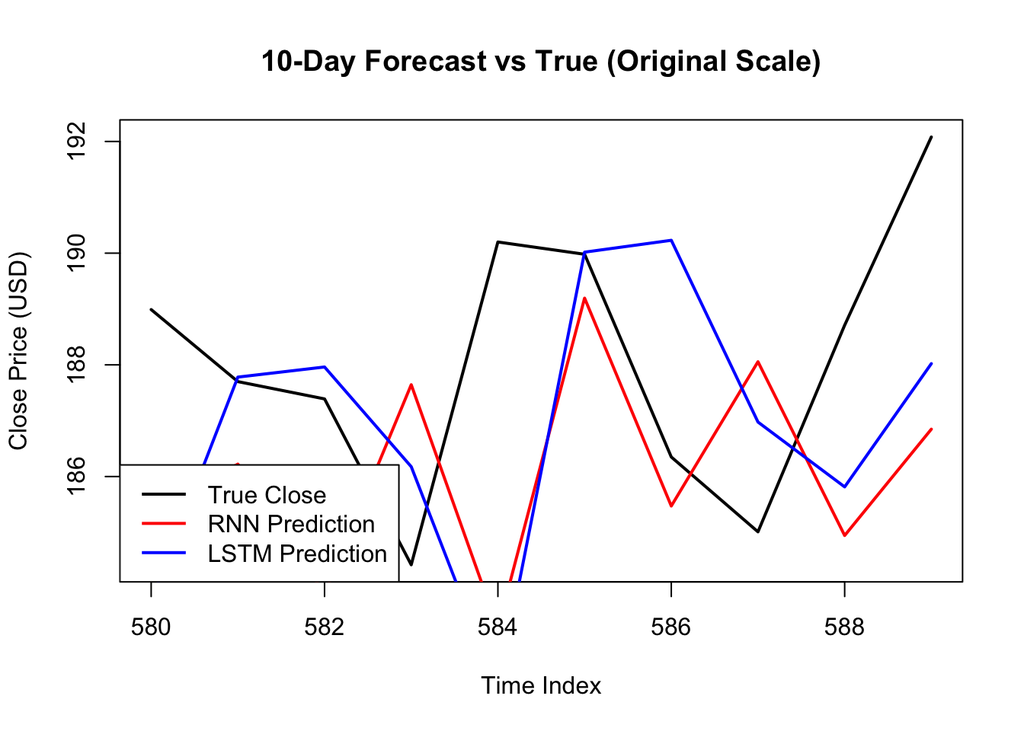

```r
plot(
  (length(train_data2)+1):(length(train_data2)+10),
  true_prices_original,
  type = 'l',
  lwd = 2,
  col = 'black',
  xlab = "Time Index",
  ylab = "Close Price (USD)",
  main = "10-Day Forecast vs True (Original Scale)"
)

lines(
  (length(train_data2)+1):(length(train_data2)+10),
  rnn_preds_original,
  col = 'red',
  lwd = 2
)

lines(
  (length(train_data2)+1):(length(train_data2)+10),
  lstm_preds_original,
  col = 'blue',
  lwd = 2
)

legend(
  "bottomleft",
  legend = c("True Close", "RNN Prediction", "LSTM Prediction"),
  col = c("black", "red", "blue"),
  lwd = 2
)
```

## Comparison

Model Test MSE (Original USD Scale)